# ISHE R Workshop: Thursday

Lisa

22/08/2019

## Load Data

```r
disgust <- read_csv("https://github.com/debruine/ishe2019/raw/master/data/disgust.csv")

users <- read_csv("https://github.com/debruine/ishe2019/raw/master/data/users.csv")
```

## Process data

### Merge tables

```r
joined_data <- left_join(disgust, users, by = "user_id")
```

### Filter

Select only rows where sex is either “male” or “female”

```r
filtered_data <- filter(joined_data, sex %in% c("male", "female"))
```

### Wide to long format

Transform from 1 row per subject and 21 questions per row, to one question:subject per row

```r
long_data <- gather(filtered_data, question, score, moral1:pathogen7)
```

### Separate a column

The new “question” column is n the format “domain#”. Split thisinto two columns for “domain” and “n”.

```r
separated_data <- separate(long_data, question, c("domain", "n"), sep = -1)
```

### Summarise

Group by domain and user_id to calculate the sum of the 7 items within each domain for each subject.

```r
grouped_data <- group_by(separated_data, domain, user_id, sex)

aggregated_data <- summarise(grouped_data, sum_score = sum(score, na.rm = FALSE))
```

### The Pipe

Or you can do this all in one step by [piping](https://psyteachr.github.io/msc-data-skills/tidyr.html#pipes). The pipe sends the results of the last function to the first argument of the next function. Remember to remove the first argument of the function when converting from separate functions to piped functions.

```r
data <- left_join(disgust, users, by = "user_id") %>%
  filter(sex %in% c("male", "female")) %>%
  gather(question, score, moral1:pathogen7) %>%
  separate(question, c("domain", "n"), sep = -1) %>%
  group_by(domain, user_id, sex)  %>%
  summarise(sum_score = sum(score, na.rm = FALSE)) %>%
  ungroup()
```

## Plot the data

### Histogram

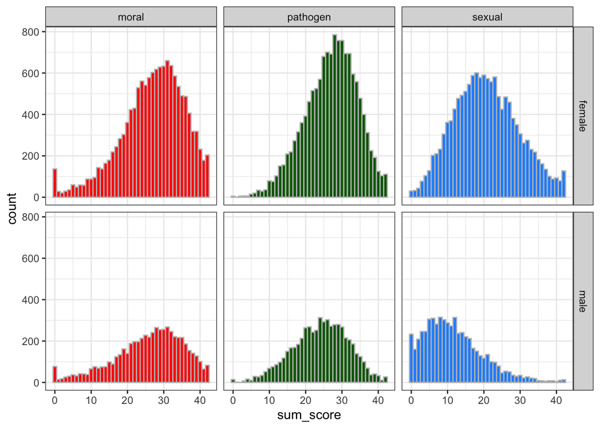

```r
ggplot(data, aes(x = sum_score, fill = domain)) +
  geom_histogram(binwidth= 1, colour = "grey", show.legend = FALSE) +
  facet_grid(sex~domain) +
  theme_bw() +
  scale_fill_manual(values = c("red", "darkgreen", "dodgerblue"))
```

### Density plot

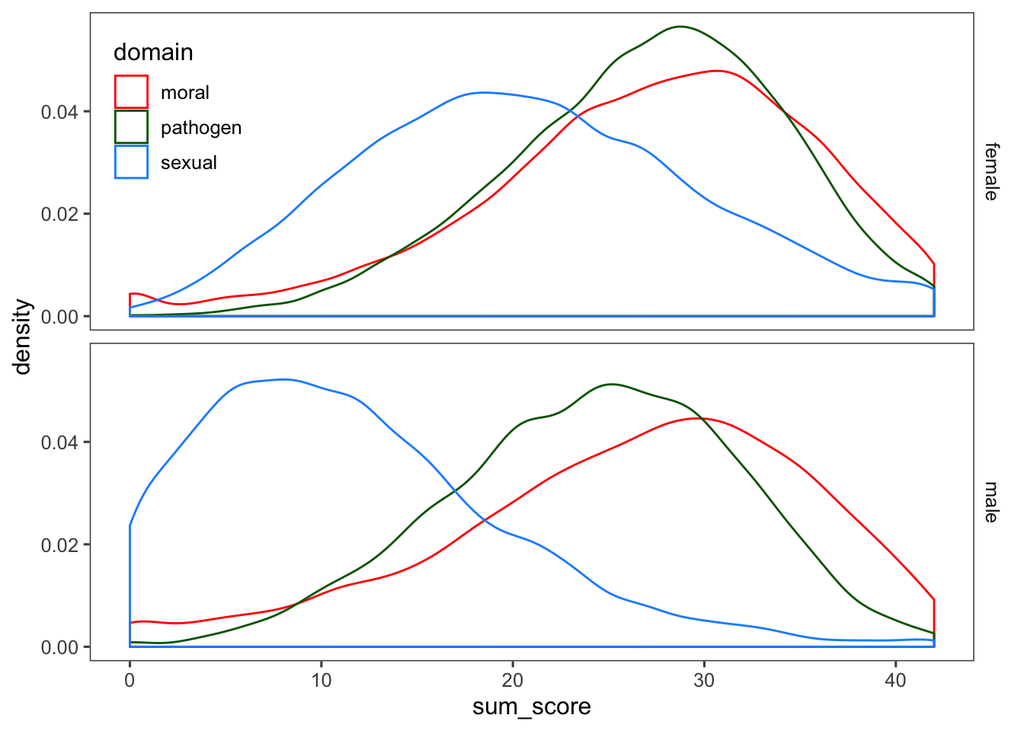

```r
ggplot(data, aes(x = sum_score, color = domain)) +
  geom_density(alpha = .5) +
  facet_grid(sex~.) +
  ggthemes::theme_few() +
  scale_color_manual(values = c("red", "darkgreen", "dodgerblue")) +
  theme(legend.position = c(.1,.85),
        legend.background = element_blank())
```

### Violin-box Plot

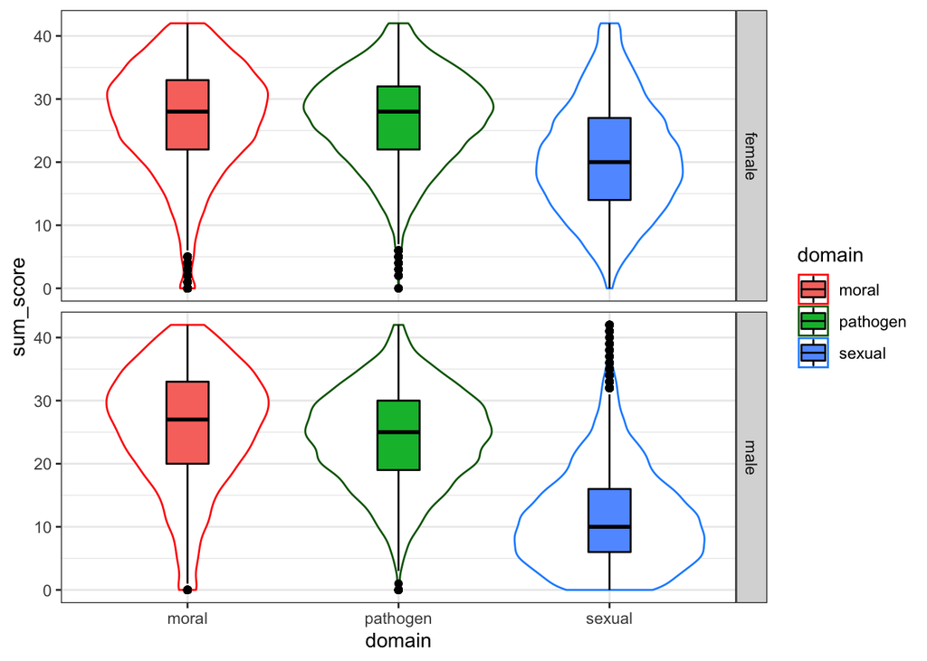

```r
ggplot(data, aes(x = domain, y = sum_score, color = domain)) +
  geom_violin() +
  geom_boxplot(aes(fill = domain), color = "black", width = .2) +
  facet_grid(sex~.) +
  theme_bw() +
  scale_color_manual(values = c("red", "darkgreen", "dodgerblue"))
```

Change the shape of the data from long to wide.

```r
data_wide <- data %>%
  spread(domain, sum_score)
```

### Line plots

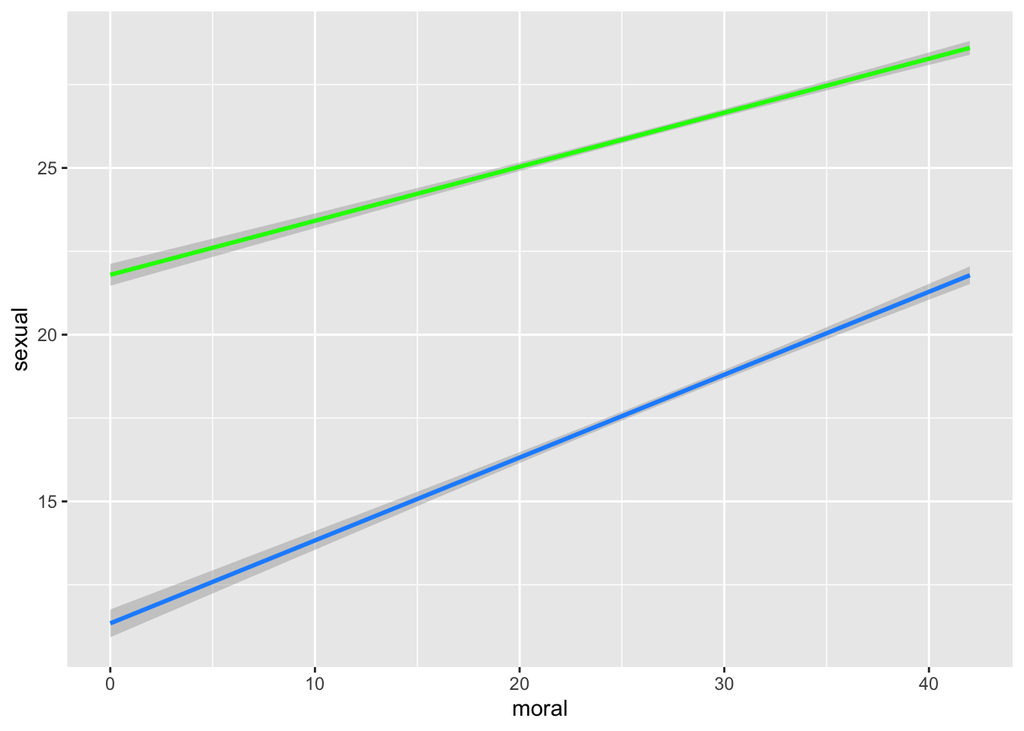

```r
ggplot(data_wide) +
  geom_smooth(aes(x = moral, y = sexual), method = lm, color = "dodgerblue") +
  geom_smooth(aes(x = moral, y = pathogen), method = lm, color = "green")
```

### Point plot

Change opacity (alpha) if there are overlapping points

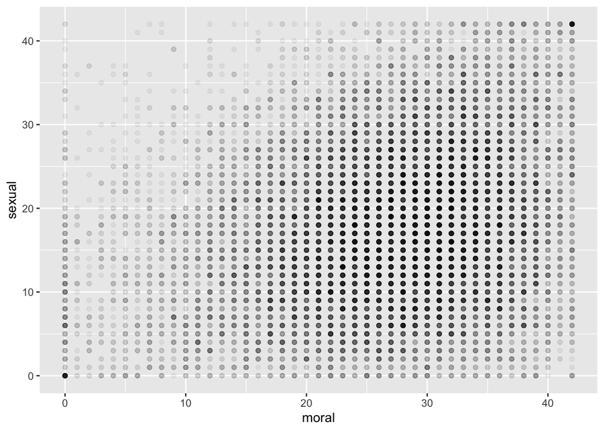

```r
ggplot(data_wide, aes(x = moral, y = sexual)) +
  geom_point(alpha = 0.05)
```

### Contour map

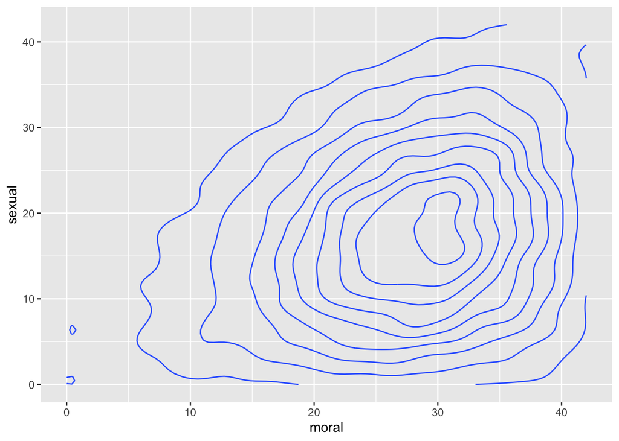

```r
ggplot(data_wide, aes(x = moral, y = sexual)) +
  geom_density2d()
```

### Heatmap

This is another way to represent densely overlapping data

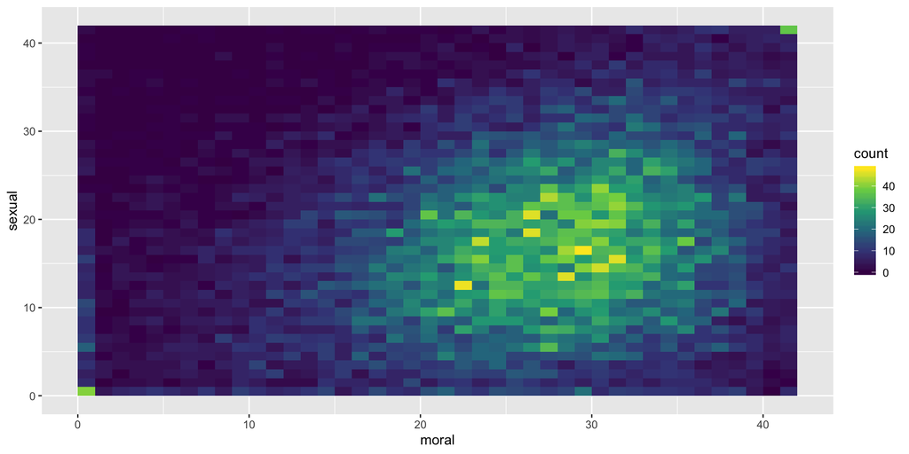

Set figure display options in the code chunk.

```r
ggplot(data_wide, aes(x = moral, y = sexual)) +
  geom_bin2d(binwidth = 1, drop = FALSE) + # set drop = TRUE to leave cells with 0 count blank
  scale_fill_viridis_c() # use the continuous viridis colour palette
```

## Save the plot

Make a folder called “fig” in your project directory and save the last image you created there.

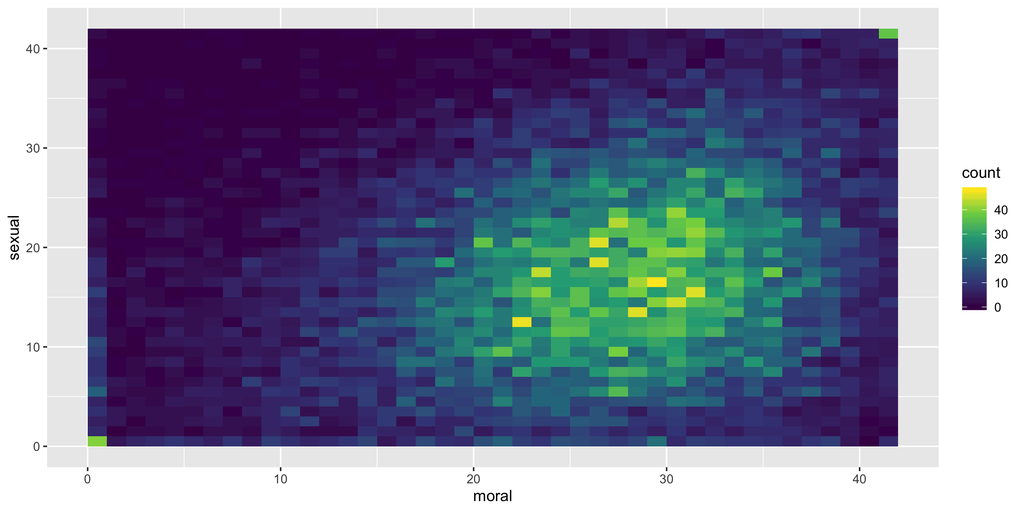

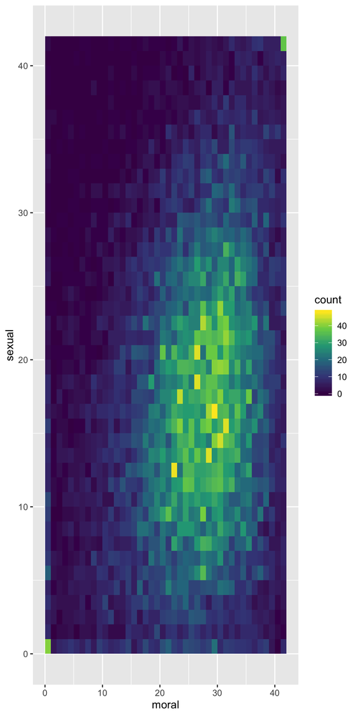

```r
ggsave("fig/wideplot.png", width = 10, height = 5)

ggsave("fig/tallplot.png", width = 5, height = 10)
```